# R Notebook

First thing to do is load the data into R, then combine the tables but save the training index to avoid having to possibly transform two tables instead of just one. Finally let’s look at the combined table.

```r
train <- read.csv("train.csv")
test <- read.csv("test.csv")
train.Id <- train$Id
test.Id <- test$Id
train$Id <- NULL
test$Id <- NULL
test$SalePrice <- NA
Houses <- rbind(train,test)
summary(Houses)
```

```
   MSSubClass        MSZoning     LotFrontage        LotArea        Street      Alley      LotShape
 Min.   : 20.00   C (all):  25   Min.   : 21.00   Min.   :  1300   Grvl:  12   Grvl: 120   IR1: 968
 1st Qu.: 20.00   FV     : 139   1st Qu.: 59.00   1st Qu.:  7478   Pave:2907   Pave:  78   IR2:  76
 Median : 50.00   RH     :  26   Median : 68.00   Median :  9453               NA's:2721   IR3:  16
 Mean   : 57.14   RL     :2265   Mean   : 69.31   Mean   : 10168                           Reg:1859
 3rd Qu.: 70.00   RM     : 460   3rd Qu.: 80.00   3rd Qu.: 11570
 Max.   :190.00   NA's   :   4   Max.   :313.00   Max.   :215245
                                 NA's   :486
 LandContour  Utilities      LotConfig    LandSlope   Neighborhood    Condition1     Condition2     BldgType
 Bnk: 117    AllPub:2916   Corner : 511   Gtl:2778   NAmes  : 443   Norm   :2511   Norm   :2889   1Fam  :2425
 HLS: 120    NoSeWa:   1   CulDSac: 176   Mod: 125   CollgCr: 267   Feedr  : 164   Feedr  :  13   2fmCon:  62
 Low:  60    NA's  :   2   FR2    :  85   Sev:  16   OldTown: 239   Artery :  92   Artery :   5   Duplex: 109
 Lvl:2622                  FR3    :  14              Edwards: 194   RRAn   :  50   PosA   :   4   Twnhs :  96
                           Inside :2133              Somerst: 182   PosN   :  39   PosN   :   4   TwnhsE: 227
                                                     NridgHt: 166   RRAe   :  28   RRNn   :   2
                                                     (Other):1428   (Other):  35   (Other):   2
   HouseStyle    OverallQual      OverallCond      YearBuilt     YearRemodAdd    RoofStyle       RoofMatl
 1Story :1471   Min.   : 1.000   Min.   :1.000   Min.   :1872   Min.   :1950   Flat   :  20   CompShg:2876
 2Story : 872   1st Qu.: 5.000   1st Qu.:5.000   1st Qu.:1954   1st Qu.:1965   Gable  :2310   Tar&Grv:  23
 1.5Fin : 314   Median : 6.000   Median :5.000   Median :1973   Median :1993   Gambrel:  22   WdShake:   9
 SLvl   : 128   Mean   : 6.089   Mean   :5.565   Mean   :1971   Mean   :1984   Hip    : 551   WdShngl:   7
 SFoyer :  83   3rd Qu.: 7.000   3rd Qu.:6.000   3rd Qu.:2001   3rd Qu.:2004   Mansard:  11   ClyTile:   1
 2.5Unf :  24   Max.   :10.000   Max.   :9.000   Max.   :2010   Max.   :2010   Shed   :   5   Membran:   1
 (Other):  27                                                                                 (Other):   2
  Exterior1st    Exterior2nd     MasVnrType     MasVnrArea     ExterQual ExterCond  Foundation   BsmtQual
 VinylSd:1025   VinylSd:1014   BrkCmn :  25   Min.   :   0.0   Ex: 107   Ex:  12   BrkTil: 311   Ex  : 258
 MetalSd: 450   MetalSd: 447   BrkFace: 879   1st Qu.:   0.0   Fa:  35   Fa:  67   CBlock:1235   Fa  :  88
 HdBoard: 442   HdBoard: 406   None   :1742   Median :   0.0   Gd: 979   Gd: 299   PConc :1308   Gd  :1209
 Wd Sdng: 411   Wd Sdng: 391   Stone  : 249   Mean   : 102.2   TA:1798   Po:   3   Slab  :  49   TA  :1283
 Plywood: 221   Plywood: 270   NA's   :  24   3rd Qu.: 164.0             TA:2538   Stone :  11   NA's:  81
 (Other): 369   (Other): 390                  Max.   :1600.0                       Wood  :   5
 NA's   :   1   NA's   :   1                  NA's   :23
 BsmtCond    BsmtExposure BsmtFinType1   BsmtFinSF1     BsmtFinType2   BsmtFinSF2        BsmtUnfSF
 Fa  : 104   Av  : 418    ALQ :429     Min.   :   0.0   ALQ :  52    Min.   :   0.00   Min.   :   0.0
 Gd  : 122   Gd  : 276    BLQ :269     1st Qu.:   0.0   BLQ :  68    1st Qu.:   0.00   1st Qu.: 220.0
 Po  :   5   Mn  : 239    GLQ :849     Median : 368.5   GLQ :  34    Median :   0.00   Median : 467.0
 TA  :2606   No  :1904    LwQ :154     Mean   : 441.4   LwQ :  87    Mean   :  49.58   Mean   : 560.8
 NA's:  82   NA's:  82    Rec :288     3rd Qu.: 733.0   Rec : 105    3rd Qu.:   0.00   3rd Qu.: 805.5
                          Unf :851     Max.   :5644.0   Unf :2493    Max.   :1526.00   Max.   :2336.0
                          NA's: 79     NA's   :1        NA's:  80    NA's   :1         NA's   :1
```

[output cut: 41 more lines]

```
 Ex  :   4   GdPrv: 118   Gar2:   5   Min.   :    0.00   Min.   : 1.000   Min.   :2006   WD     :2525
 Fa  :   2   GdWo : 112   Othr:   4   1st Qu.:    0.00   1st Qu.: 4.000   1st Qu.:2007   New    : 239
 Gd  :   4   MnPrv: 329   Shed:  95   Median :    0.00   Median : 6.000   Median :2008   COD    :  87
 NA's:2909   MnWw :  12   TenC:   1   Mean   :   50.83   Mean   : 6.213   Mean   :2008   ConLD  :  26
             NA's :2348   NA's:2814   3rd Qu.:    0.00   3rd Qu.: 8.000   3rd Qu.:2009   CWD    :  12
                                      Max.   :17000.00   Max.   :12.000   Max.   :2010   (Other):  29
                                                                                         NA's   :   1
 SaleCondition    SalePrice
 Abnorml: 190   Min.   : 34900
 AdjLand:  12   1st Qu.:129975
 Alloca :  24   Median :163000
 Family :  46   Mean   :180921
 Normal :2402   3rd Qu.:214000
 Partial: 245   Max.   :755000
                NA's   :1459
```

```r
str(Houses)
```

```
'data.frame':   2919 obs. of  80 variables:
 $ MSSubClass   : int  60 20 60 70 60 50 20 60 50 190 ...
 $ MSZoning     : Factor w/ 5 levels "C (all)","FV",..: 4 4 4 4 4 4 4 4 5 4 ...
 $ LotFrontage  : int  65 80 68 60 84 85 75 NA 51 50 ...
 $ LotArea      : int  8450 9600 11250 9550 14260 14115 10084 10382 6120 7420 ...
 $ Street       : Factor w/ 2 levels "Grvl","Pave": 2 2 2 2 2 2 2 2 2 2 ...
 $ Alley        : Factor w/ 2 levels "Grvl","Pave": NA NA NA NA NA NA NA NA NA NA ...
 $ LotShape     : Factor w/ 4 levels "IR1","IR2","IR3",..: 4 4 1 1 1 1 4 1 4 4 ...
 $ LandContour  : Factor w/ 4 levels "Bnk","HLS","Low",..: 4 4 4 4 4 4 4 4 4 4 ...
 $ Utilities    : Factor w/ 2 levels "AllPub","NoSeWa": 1 1 1 1 1 1 1 1 1 1 ...
 $ LotConfig    : Factor w/ 5 levels "Corner","CulDSac",..: 5 3 5 1 3 5 5 1 5 1 ...
 $ LandSlope    : Factor w/ 3 levels "Gtl","Mod","Sev": 1 1 1 1 1 1 1 1 1 1 ...
 $ Neighborhood : Factor w/ 25 levels "Blmngtn","Blueste",..: 6 25 6 7 14 12 21 17 18 4 ...
 $ Condition1   : Factor w/ 9 levels "Artery","Feedr",..: 3 2 3 3 3 3 3 5 1 1 ...
 $ Condition2   : Factor w/ 8 levels "Artery","Feedr",..: 3 3 3 3 3 3 3 3 3 1 ...
```

[output cut: 66 more lines]

Remove features that have very low variance or a large amount of NAs and that also look not very useful.

```r
Houses$Street <- NULL
Houses$Alley <- NULL
Houses$Utilities <- NULL
Houses$Condition2 <- NULL
Houses$RoofMatl <- NULL
Houses$BsmtCond <- NULL
Houses$BsmtFinSF2 <- NULL
Houses$Heating <- NULL
Houses$CentralAir <- NULL
Houses$LowQualFinSF <- NULL
Houses$BsmtHalfBath <- NULL
Houses$Functional <- NULL
Houses$FireplaceQu <- NULL
Houses$GarageQual <- NULL
Houses$GarageCond <- NULL
Houses$PoolQC <- NULL
Houses$Fence <- NULL
```

Lot Frontage varies considerably by neighborhood, so imputing the missing data based on the mean lot frontage per neighborhood seems reasonable.

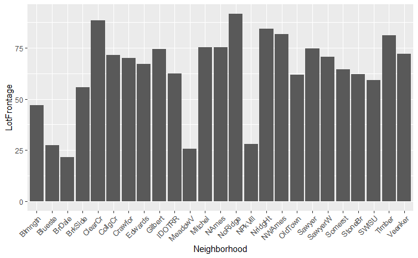

```r
library(ggplot2)
ggplot(Houses, aes(x=Neighborhood, y=LotFrontage)) + stat_summary(fun.y="mean", geom="bar") + theme(axis.text.x = element_text(angle = 45, hjust = 1))
```

```r
for(i in 1:nrow(Houses)){
  if(is.na(Houses$LotFrontage[i])){
    Houses$LotFrontage[i] <- mean(Houses$LotFrontage[Houses$Neighborhood==Houses$Neighborhood[i]], na.rm=T)
  }}
```

We see that for the 23 rows with NAs in MasVnrArea, each of them also had an NA entry for MasVnrType. This leaves us with only one NA MasVnrType entry where the input for MasMasVnrArea is not an NA. We will impute the mode, which is “None” and 0 for MasVnrType and MasVnrArea respectively for the 23 entires with NAs in both slots and the mode for all values that are *not* “None” for the one other NA, which is “BrkFace”.

```r
Houses[is.na(Houses$MasVnrType),]
```

|  | MSSubClass | MSZoning | LotFrontage | LotArea | LotShape | LandContour | LotConfig | LandSlope | Neighborhood | Condition1 | BldgType | HouseStyle | OverallQual | OverallCond | YearBuilt | YearRemodAdd | RoofStyle | Exterior1st | Exterior2nd | MasVnrType | MasVnrArea | ExterQual | ExterCond | Foundation | BsmtQual | BsmtExposure | BsmtFinType1 | BsmtFinSF1 | BsmtFinType2 | … |
| --- | --- | --- | --- | --- | --- | --- | --- | --- | --- | --- | --- | --- | --- | --- | --- | --- | --- | --- | --- | --- | --- | --- | --- | --- | --- | --- | --- | --- | --- | --- |
| 235 | 60 | RL | 74.20721 | 7851 | Reg | Lvl | Inside | Gtl | Gilbert | Norm | 1Fam | 2Story | 6 | 5 | 2002 | 2002 | Gable | VinylSd | VinylSd | NA | NA | Gd | TA | PConc | Gd | No | GLQ | 625 | Unf | … |
| 530 | 20 | RL | 69.95181 | 32668 | IR1 | Lvl | CulDSac | Gtl | Crawfor | Norm | 1Fam | 1Story | 6 | 3 | 1957 | 1975 | Hip | Wd Sdng | Stone | NA | NA | Gd | TA | PConc | TA | No | Rec | 1219 | Unf | … |
| 651 | 60 | FV | 65.00000 | 8125 | Reg | Lvl | Inside | Gtl | Somerst | Norm | 1Fam | 2Story | 7 | 6 | 2007 | 2007 | Gable | CemntBd | CmentBd | NA | NA | Gd | TA | PConc | Gd | No | Unf | 0 | Unf | … |
| 937 | 20 | RL | 67.00000 | 10083 | Reg | Lvl | Inside | Gtl | SawyerW | Norm | 1Fam | 1Story | 7 | 5 | 2003 | 2003 | Gable | VinylSd | VinylSd | NA | NA | Gd | TA | PConc | Gd | No | GLQ | 833 | Unf | … |
| 974 | 20 | FV | 95.00000 | 11639 | Reg | Lvl | Corner | Gtl | Somerst | Norm | 1Fam | 1Story | 7 | 5 | 2007 | 2008 | Gable | CemntBd | CmentBd | NA | NA | Gd | TA | PConc | Gd | No | Unf | 0 | Unf | … |
| 978 | 120 | FV | 35.00000 | 4274 | IR1 | Lvl | Inside | Gtl | Somerst | Norm | TwnhsE | 1Story | 7 | 5 | 2006 | 2007 | Gable | VinylSd | VinylSd | NA | NA | Gd | TA | PConc | Gd | No | GLQ | 1106 | Unf | … |
| 1244 | 20 | RL | 107.00000 | 13891 | Reg | Lvl | Inside | Gtl | NridgHt | Norm | 1Fam | 1Story | 10 | 5 | 2006 | 2006 | Gable | VinylSd | VinylSd | NA | NA | Ex | TA | PConc | Ex | Gd | GLQ | 1386 | Unf | … |
| 1279 | 60 | RL | 75.00000 | 9473 | Reg | Lvl | Inside | Gtl | CollgCr | Norm | 1Fam | 2Story | 8 | 5 | 2002 | 2002 | Gable | VinylSd | VinylSd | NA | NA | Gd | TA | PConc | Gd | No | GLQ | 804 | Unf | … |
| 1692 | 60 | RL | 74.20721 | 12891 | IR1 | Lvl | Corner | Gtl | Gilbert | Norm | 1Fam | 2Story | 8 | 5 | 2002 | 2002 | Gable | VinylSd | VinylSd | NA | NA | Gd | TA | PConc | Ex | No | GLQ | 651 | Unf | … |
| 1707 | 20 | FV | 90.00000 | 7993 | IR1 | Lvl | Inside | Gtl | Somerst | Norm | 1Fam | 1Story | 7 | 5 | 2008 | 2009 | Gable | VinylSd | VinylSd | NA | NA | Gd | TA | PConc | Ex | No | Unf | 0 | Unf | … |

[output cut: 14 more lines]

```r
Houses$MasVnrType[is.na(Houses$MasVnrType)&!is.na(Houses$MasVnrArea)] <- "BrkFace"
Houses$MasVnrType[is.na(Houses$MasVnrType)] <- "None"
Houses$MasVnrArea[is.na(Houses$MasVnrArea)] <- 0
```

For houses without a basement, we impute the missing values for BsmtExposure, BsmtExposure, BsmtFinType1, BsmtFinType2 with “No Bsmt”

```r
Houses[Houses$TotalBsmtSF==0,]
```

|  | MSSubClass | MSZoning | LotFrontage | LotArea | LotShape | LandContour | LotConfig | LandSlope | Neighborhood | Condition1 | BldgType | HouseStyle | OverallQual | OverallCond | YearBuilt | YearRemodAdd | RoofStyle | Exterior1st | Exterior2nd | MasVnrType | MasVnrArea | ExterQual | ExterCond | Foundation | BsmtQual | BsmtExposure | BsmtFinType1 | BsmtFinSF1 | BsmtFinType2 | … |
| --- | --- | --- | --- | --- | --- | --- | --- | --- | --- | --- | --- | --- | --- | --- | --- | --- | --- | --- | --- | --- | --- | --- | --- | --- | --- | --- | --- | --- | --- | --- |
| 18 | 90 | RL | 72.00000 | 10791 | Reg | Lvl | Inside | Gtl | Sawyer | Norm | Duplex | 1Story | 4 | 5 | 1967 | 1967 | Gable | MetalSd | MetalSd | None | 0 | TA | TA | Slab | NA | NA | NA | 0 | NA | … |
| 40 | 90 | RL | 65.00000 | 6040 | Reg | Lvl | Inside | Gtl | Edwards | Norm | Duplex | 1Story | 4 | 5 | 1955 | 1955 | Gable | AsbShng | Plywood | None | 0 | TA | TA | PConc | NA | NA | NA | 0 | NA | … |
| 91 | 20 | RL | 60.00000 | 7200 | Reg | Lvl | Inside | Gtl | NAmes | Norm | 1Fam | 1Story | 4 | 5 | 1950 | 1950 | Gable | BrkFace | Wd Sdng | None | 0 | TA | TA | Slab | NA | NA | NA | 0 | NA | … |
| 103 | 90 | RL | 64.00000 | 7018 | Reg | Bnk | Inside | Gtl | SawyerW | Norm | Duplex | 1Story | 5 | 5 | 1979 | 1979 | Gable | HdBoard | HdBoard | None | 0 | TA | Fa | Slab | NA | NA | NA | 0 | NA | … |
| 157 | 20 | RL | 60.00000 | 7200 | Reg | Lvl | Inside | Gtl | NAmes | Norm | 1Fam | 1Story | 5 | 7 | 1950 | 1950 | Hip | Wd Sdng | Wd Sdng | None | 0 | TA | TA | CBlock | NA | NA | NA | 0 | NA | … |
| 183 | 20 | RL | 60.00000 | 9060 | Reg | Lvl | Inside | Gtl | Edwards | Artery | 1Fam | 1Story | 5 | 6 | 1957 | 2006 | Hip | Wd Sdng | Wd Sdng | BrkFace | 98 | TA | TA | PConc | NA | NA | NA | 0 | NA | … |
| 260 | 20 | RM | 70.00000 | 12702 | Reg | Lvl | Inside | Gtl | OldTown | Norm | 1Fam | 1Story | 5 | 5 | 1956 | 1956 | Gable | BrkFace | BrkFace | None | 0 | TA | TA | PConc | NA | NA | NA | 0 | NA | … |
| 343 | 90 | RL | 75.21067 | 8544 | Reg | Lvl | Inside | Gtl | NAmes | Norm | Duplex | 1Story | 3 | 4 | 1949 | 1950 | Gable | Stucco | Stucco | BrkFace | 340 | TA | TA | Slab | NA | NA | NA | 0 | NA | … |
| 363 | 85 | RL | 64.00000 | 7301 | Reg | Lvl | Corner | Gtl | Edwards | Norm | 1Fam | SFoyer | 7 | 5 | 2003 | 2003 | Gable | HdBoard | HdBoard | BrkFace | 500 | Gd | TA | Slab | NA | NA | NA | 0 | NA | … |
| 372 | 50 | RL | 80.00000 | 17120 | Reg | Lvl | Inside | Gtl | ClearCr | Feedr | 1Fam | 1.5Fin | 4 | 4 | 1959 | 1959 | Gable | WdShing | Plywood | None | 0 | TA | TA | CBlock | NA | NA | NA | 0 | NA | … |

[output cut: 69 more lines]

```r
levels(Houses$BsmtQual) <- c(levels(Houses$BsmtQual),"No Bsmt")
levels(Houses$BsmtExposure) <- c(levels(Houses$BsmtExposure),"No Bsmt")
levels(Houses$BsmtFinType1) <- c(levels(Houses$BsmtFinType1),"No Bsmt")
levels(Houses$BsmtFinType2) <- c(levels(Houses$BsmtFinType2),"No Bsmt")
Houses$BsmtQual[Houses$TotalBsmtSF==0] <- "No Bsmt"
Houses$BsmtExposure[Houses$TotalBsmtSF==0] <- "No Bsmt"
Houses$BsmtFinType1[Houses$TotalBsmtSF==0] <- "No Bsmt"
Houses$BsmtFinType2[Houses$TotalBsmtSF==0] <- "No Bsmt"
```

For all the other NA entries for these four predictors, we will impute the mode.

```r
Houses[is.na(Houses$BsmtQual)|is.na(Houses$BsmtExposure)|is.na(Houses$BsmtFinType1)|is.na(Houses$BsmtFinType2),]
```

|  | MSSubClass | MSZoning | LotFrontage | LotArea | LotShape | LandContour | LotConfig | LandSlope | Neighborhood | Condition1 | BldgType | HouseStyle | OverallQual | OverallCond | YearBuilt | YearRemodAdd | RoofStyle | Exterior1st | Exterior2nd | MasVnrType | MasVnrArea | ExterQual | ExterCond | Foundation | BsmtQual | BsmtExposure | BsmtFinType1 | BsmtFinSF1 | BsmtFinType2 | … |
| --- | --- | --- | --- | --- | --- | --- | --- | --- | --- | --- | --- | --- | --- | --- | --- | --- | --- | --- | --- | --- | --- | --- | --- | --- | --- | --- | --- | --- | --- | --- |
| 333 | 20 | RL | 85 | 10655 | IR1 | Lvl | Inside | Gtl | NridgHt | Norm | 1Fam | 1Story | 8 | 5 | 2003 | 2004 | Gable | VinylSd | VinylSd | BrkFace | 296 | Gd | TA | PConc | Gd | No | GLQ | 1124 | NA | … |
| 949 | 60 | RL | 65 | 14006 | IR1 | Lvl | Inside | Gtl | CollgCr | Norm | 1Fam | 2Story | 7 | 5 | 2002 | 2002 | Gable | VinylSd | VinylSd | BrkFace | 144 | Gd | TA | PConc | Gd | NA | Unf | 0 | Unf | … |
| 1488 | 20 | RL | 73 | 8987 | Reg | Lvl | Inside | Gtl | Somerst | Norm | 1Fam | 1Story | 8 | 5 | 2005 | 2006 | Gable | VinylSd | VinylSd | BrkFace | 226 | Gd | TA | PConc | Gd | NA | Unf | 0 | Unf | … |
| 2121 | 20 | RM | 99 | 5940 | IR1 | Lvl | FR3 | Gtl | BrkSide | Feedr | 1Fam | 1Story | 4 | 7 | 1946 | 1950 | Gable | MetalSd | CBlock | None | 0 | TA | TA | PConc | NA | NA | NA | NA | NA | … |
| 2218 | 70 | C (all) | 60 | 5280 | Reg | Lvl | Corner | Gtl | IDOTRR | Feedr | 1Fam | 2Story | 4 | 7 | 1895 | 1950 | Gable | Wd Sdng | Wd Sdng | None | 0 | TA | TA | Stone | NA | No | Unf | 0 | Unf | … |
| 2219 | 50 | C (all) | 52 | 5150 | Reg | Lvl | Corner | Gtl | IDOTRR | Feedr | 1Fam | 1.5Fin | 4 | 7 | 1910 | 2000 | Gable | Plywood | Plywood | None | 0 | TA | TA | PConc | NA | No | Unf | 0 | Unf | … |
| 2349 | 60 | FV | 81 | 10411 | Reg | Lvl | Corner | Gtl | Somerst | Norm | 1Fam | 2Story | 5 | 5 | 2007 | 2007 | Gable | VinylSd | VinylSd | None | 0 | Gd | TA | CBlock | Gd | NA | Unf | 0 | Unf | … |

```r
Houses$BsmtQual[is.na(Houses$BsmtQual)] <- "TA"
Houses$BsmtExposure[is.na(Houses$BsmtExposure)] <- "No"
Houses$BsmtFinType1[is.na(Houses$BsmtFinType1)] <- "Unf"
Houses$BsmtFinType2[is.na(Houses$BsmtFinType2)] <- "Unf"
```

First let’s impute the obvious values for NAs in GarageType and GarageFinish.

```r
levels(Houses$GarageType) <- c(levels(Houses$GarageType), "No Garage")
levels(Houses$GarageFinish) <- c(levels(Houses$GarageFinish), "No Garage")
Houses$GarageType[Houses$GarageArea==0] <- "No Garage"
Houses$GarageFinish[Houses$GarageArea==0] <- "No Garage"
```

For the other two NAs in GarageFinish where the house actually has a garage, we see that they both have the value “Detchd” for GarageType. Upon using a table, we see that by far the most common value for this type of garage is “Unf”.

```r
Houses[is.na(Houses$GarageFinish),]
```

|  | MSSubClass | MSZoning | LotFrontage | LotArea | LotShape | LandContour | LotConfig | LandSlope | Neighborhood | Condition1 | BldgType | HouseStyle | OverallQual | OverallCond | YearBuilt | YearRemodAdd | RoofStyle | Exterior1st | Exterior2nd | MasVnrType | MasVnrArea | ExterQual | ExterCond | Foundation | BsmtQual | BsmtExposure | BsmtFinType1 | BsmtFinSF1 | BsmtFinType2 | … |
| --- | --- | --- | --- | --- | --- | --- | --- | --- | --- | --- | --- | --- | --- | --- | --- | --- | --- | --- | --- | --- | --- | --- | --- | --- | --- | --- | --- | --- | --- | --- |
| 2127 | 60 | RM | 57 | 8094 | Reg | Lvl | Inside | Gtl | OldTown | Norm | 2fmCon | 2.5Unf | 6 | 8 | 1910 | 1983 | Gable | Wd Sdng | Wd Sdng | None | 0 | TA | TA | PConc | TA | Mn | Rec | 196 | Unf | … |
| 2577 | 70 | RM | 50 | 9060 | Reg | Lvl | Inside | Gtl | IDOTRR | Norm | 1Fam | 2Story | 5 | 6 | 1923 | 1999 | Gable | Wd Sdng | Plywood | None | 0 | TA | TA | BrkTil | Gd | No | ALQ | 548 | Unf | … |

```r
table(Houses$GarageType, Houses$GarageFinish)
```

```
            Fin RFn Unf No Garage
  2Types      3   5  15         0
  Attchd    554 716 453         0
  Basment    11   8  17         0
  BuiltIn   127  48  11         0
  CarPort     0   0  15         0
  Detchd     24  34 719         0
  No Garage   0   0   0       157
```

```r
Houses$GarageFinish[is.na(Houses$GarageFinish)] <- "Unf"
```

For houses with no garage, we impute 0 for GarageYrblt and insert a dummy variable for whether the house has a garage or not. Also for houses with a Garage but that have an NA value for GarageYrBlt, we can simply impute the year the house was built.

```r
Houses$GarageYrBlt[is.na(Houses$GarageYrBlt) & Houses$GarageType != "No Garage"] <- Houses$YearBuilt[is.na(Houses$GarageYrBlt) & Houses$GarageType != "No Garage"]
```

```r
Houses$GarageYrBlt[is.na(Houses$GarageYrBlt)] <- 0
```

```r
Houses$HasGarage <- factor(ifelse(Houses$GarageType != "No Garage", "yes", "no"), levels = c("yes", "no"))
```

Looking at the summary, there is an obvious mistake in a GarageYrBlt entry. Since it seems like the intention was to input 2007 and that was also when the house was last remodeled, it makes sense for us to replace the error with 2007.

```r
Houses[Houses$GarageYrBlt == 2207,]
```

|  | MSSubClass | MSZoning | LotFrontage | LotArea | LotShape | LandContour | LotConfig | LandSlope | Neighborhood | Condition1 | BldgType | HouseStyle | OverallQual | OverallCond | YearBuilt | YearRemodAdd | RoofStyle | Exterior1st | Exterior2nd | MasVnrType | MasVnrArea | ExterQual | ExterCond | Foundation | BsmtQual | BsmtExposure | BsmtFinType1 | BsmtFinSF1 | BsmtFinType2 | … |
| --- | --- | --- | --- | --- | --- | --- | --- | --- | --- | --- | --- | --- | --- | --- | --- | --- | --- | --- | --- | --- | --- | --- | --- | --- | --- | --- | --- | --- | --- | --- |
| 2593 | 20 | RL | 68 | 8298 | IR1 | HLS | Inside | Gtl | Timber | Norm | 1Fam | 1Story | 8 | 5 | 2006 | 2007 | Hip | VinylSd | VinylSd | None | 0 | Gd | TA | PConc | Gd | Av | GLQ | 583 | Unf | … |

```r
Houses$GarageYrBlt[Houses$GarageYrBlt == 2207] <- 2007
```

For the MiscFeature variable, simply replace the NAs with “None”.

```r
levels(Houses$MiscFeature) <- c(levels(Houses$MiscFeature), "None")
Houses$MiscFeature[is.na(Houses$MiscFeature)] <- "None"
```

Finally, the following variables each have only a handful of NAs at most and such we can simply impute them with the mean if numeric or mode if categorical.

```r
Houses$MSZoning[is.na(Houses$MSZoning)] <- "RL"
Houses$Exterior1st[is.na(Houses$Exterior1st)] <- "VinylSd"
Houses$Exterior2nd[is.na(Houses$Exterior2nd)] <- "VinylSd"
Houses$BsmtFinSF1[is.na(Houses$BsmtFinSF1)] <- 441.4
Houses$BsmtUnfSF[is.na(Houses$BsmtUnfSF)] <- 560.8
Houses$TotalBsmtSF[is.na(Houses$TotalBsmtSF)] <- 1051.8
Houses$Electrical[is.na(Houses$Electrical)] <- "SBrkr"
Houses$BsmtFullBath[is.na(Houses$BsmtFullBath)] <- 0
Houses$KitchenQual[is.na(Houses$KitchenQual)] <- "TA"
Houses$GarageCars[is.na(Houses$GarageCars)] <- 2
Houses$GarageArea[is.na(Houses$GarageArea)] <- 472.9
Houses$SaleType[is.na(Houses$SaleType)] <- "WD"
```

from the pdf associated with this dataset, we are informed that there are five outliers that have GrLiveArea > 4000. We can remove the four that are in the training set, but not the one in the test set.

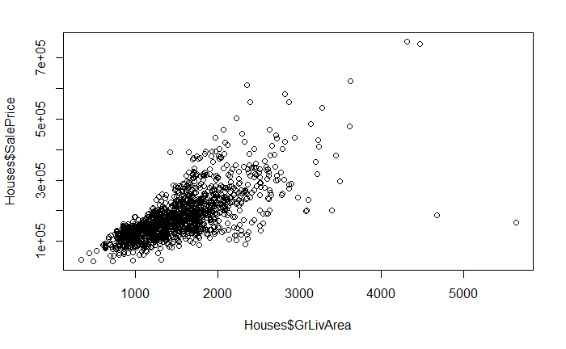

```r
plot(Houses$GrLivArea, Houses$SalePrice)
```

```r
Houses[Houses$GrLivArea > 4000,]
```

|  | MSSubClass | MSZoning | LotFrontage | LotArea | LotShape | LandContour | LotConfig | LandSlope | Neighborhood | Condition1 | BldgType | HouseStyle | OverallQual | OverallCond | YearBuilt | YearRemodAdd | RoofStyle | Exterior1st | Exterior2nd | MasVnrType | MasVnrArea | ExterQual | ExterCond | Foundation | BsmtQual | BsmtExposure | BsmtFinType1 | BsmtFinSF1 | BsmtFinType2 | … |
| --- | --- | --- | --- | --- | --- | --- | --- | --- | --- | --- | --- | --- | --- | --- | --- | --- | --- | --- | --- | --- | --- | --- | --- | --- | --- | --- | --- | --- | --- | --- |
| 524 | 60 | RL | 130 | 40094 | IR1 | Bnk | Inside | Gtl | Edwards | PosN | 1Fam | 2Story | 10 | 5 | 2007 | 2008 | Hip | CemntBd | CmentBd | Stone | 762 | Ex | TA | PConc | Ex | Gd | GLQ | 2260 | Unf | … |
| 692 | 60 | RL | 104 | 21535 | IR1 | Lvl | Corner | Gtl | NoRidge | Norm | 1Fam | 2Story | 10 | 6 | 1994 | 1995 | Gable | HdBoard | HdBoard | BrkFace | 1170 | Ex | TA | PConc | Ex | Gd | GLQ | 1455 | Unf | … |
| 1183 | 60 | RL | 160 | 15623 | IR1 | Lvl | Corner | Gtl | NoRidge | Norm | 1Fam | 2Story | 10 | 5 | 1996 | 1996 | Hip | Wd Sdng | ImStucc | None | 0 | Gd | TA | PConc | Ex | Av | GLQ | 2096 | Unf | … |
| 1299 | 60 | RL | 313 | 63887 | IR3 | Bnk | Corner | Gtl | Edwards | Feedr | 1Fam | 2Story | 10 | 5 | 2008 | 2008 | Hip | Stucco | Stucco | Stone | 796 | Ex | TA | PConc | Ex | Gd | GLQ | 5644 | Unf | … |
| 2550 | 20 | RL | 128 | 39290 | IR1 | Bnk | Inside | Gtl | Edwards | Norm | 1Fam | 1Story | 10 | 5 | 2008 | 2009 | Hip | CemntBd | CmentBd | Stone | 1224 | Ex | TA | PConc | Ex | Gd | GLQ | 4010 | Unf | … |

```r
Houses <- Houses[-c(524, 692, 1183, 1299),]
train.Id <- which(!is.na(Houses$SalePrice))
```

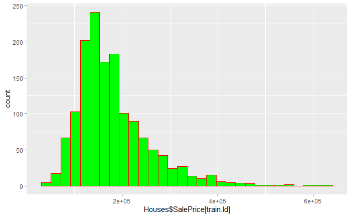

```r
ggplot(data=Houses[train.Id,], aes(x=Houses$SalePrice[train.Id])) + geom_histogram(col="red", fill = "green")
```

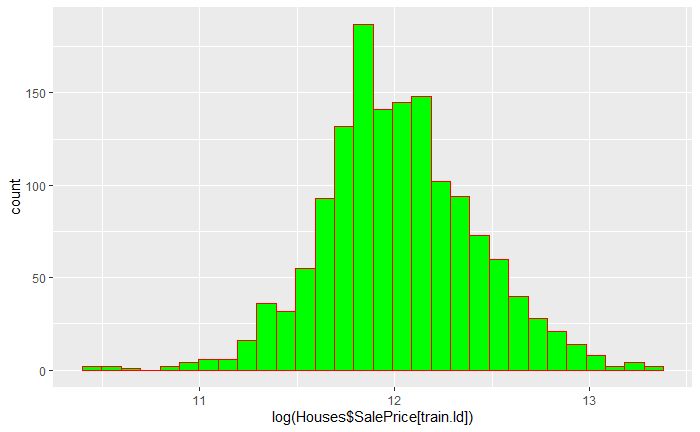

```r
ggplot(data=Houses[train.Id,], aes(x=log(Houses$SalePrice[train.Id]))) + geom_histogram(col="red", fill="green")
```

Some Feature Engineering

```r
Houses$TotalSF <- Houses$TotalBsmtSF + Houses$X2ndFlrSF + Houses$X1stFlrSF
Houses$Has2ndFlr <- factor(ifelse(Houses$X2ndFlrSF > 0, "yes", "no"), levels = c("yes","no"))
continuous.var.names <- c(continuous.var.names, "TotalSF")
```

These predictors are really qualitative and not quantitative.

```r
Houses$MSSubClass <- factor(Houses$MSSubClass)
Houses$MoSold <- factor(Houses$MoSold)
#Houses$OverallQual <- factor(Houses$OverallQual, ordered = T)
#Houses$BsmtFullBath <- factor(Houses$BsmtFullBath)
#Houses$HalfBath <- factor(Houses$HalfBath)
#Houses$FullBath <- factor(Houses$FullBath)
#Houses$BedroomAbvGr <- factor(Houses$BedroomAbvGr)
Houses$KitchenAbvGr <- factor(Houses$KitchenAbvGr)
#Houses$TotRmsAbvGrd <- factor(Houses$TotRmsAbvGrd)
#Houses$Fireplaces <- factor(Houses$Fireplaces)
#Houses$GarageCars <- factor(Houses$GarageCars)
```

#### Porch Variables

Only Open Porch has a correlation that is not really low, so it makes sense to combine these variables then create a factor variable indicating the presense of each type of porch, other than the 3 seasons one as it is most likely insignificant, then also turn Total Porch Area using the cut function.

```r
Houses$TotalPorchArea <- Houses$X3SsnPorch + Houses$OpenPorchSF + Houses$ScreenPorch + Houses$EnclosedPorch
Houses$HasOpenPorch <- factor(ifelse(Houses$OpenPorchSF > 0, "yes", "no"), levels = c("yes","no"))
Houses$HasEnclosedPorch <- factor(ifelse(Houses$EnclosedPorch > 0, "yes", "no"), levels = c("yes","no"))
Houses$HasScreenPorch <- factor(ifelse(Houses$ScreenPorch > 0, "yes", "no"), levels = c("yes","no"))
```

```r
summary(aov(log(SalePrice)~HasEnclosedPorch+HasOpenPorch+HasScreenPorch+TotalPorchArea*OpenPorchSF, data = Houses[train.Id,]))
```

[output not shown]

```r
continuous.var.names <- c("YrSold","MiscVal","PoolArea","ScreenPorch","X3SsnPorch","EnclosedPorch", "OpenPorchSF","WoodDeckSF","GarageArea","GarageYrBlt", "GrLivArea","X2ndFlrSF","X1stFlrSF","TotalBsmtSF", "BsmtUnfSF", "BsmtFinSF1","MasVnrArea","YearRemodAdd","YearBuilt","LotArea","LotFrontage","TotalSF","PorchArea")
for(i in 1:length(continuous.var.names)){
  print(continuous.var.names[i])
  print(x=cor(log(Houses$SalePrice[train.Id]), y=as.numeric(Houses[train.Id, continuous.var.names[i]])))
   }
```

```
[1] "YrSold"
[1] -0.0343189
[1] "MiscVal"
[1] -0.01975174
[1] "PoolArea"
[1] 0.0406788
[1] "ScreenPorch"
[1] 0.1238603
[1] "X3SsnPorch"
[1] 0.05606492
[1] "EnclosedPorch"
[1] -0.1486365
[1] "OpenPorchSF"
[1] 0.327038
[1] "WoodDeckSF"
```

[output cut: 30 more lines]

```
Error in cor(log(Houses$SalePrice[train.Id]), y = as.numeric(Houses[train.Id,  :
  incompatible dimensions
```

```r
`%notin%` <- Negate(`%in%`)
categorical.var.names <- colnames(Houses)[colnames(Houses) %notin% continuous.var.names]
for(i in 1:length(categorical.var.names)){
  print(categorical.var.names[i])
  print(summary(aov(log(Houses$SalePrice[train.Id])~Houses[train.Id,categorical.var.names[i]]))) }
```

```
[1] "MSSubClass"
                                             Df Sum Sq Mean Sq F value Pr(>F)
Houses[train.Id, categorical.var.names[i]]   14  75.32   5.380   50.69 <2e-16 ***
Residuals                                  1441 152.94   0.106
---
Signif. codes:  0 â***â 0.001 â**â 0.01 â*â 0.05 â.â 0.1 â â 1
[1] "MSZoning"
                                             Df Sum Sq Mean Sq F value Pr(>F)
Houses[train.Id, categorical.var.names[i]]    4  40.57  10.143   78.41 <2e-16 ***
Residuals                                  1451 187.69   0.129
---
Signif. codes:  0 â***â 0.001 â**â 0.01 â*â 0.05 â.â 0.1 â â 1
[1] "LotShape"
                                             Df Sum Sq Mean Sq F value Pr(>F)
Houses[train.Id, categorical.var.names[i]]    3   19.7   6.566   45.72 <2e-16 ***
Residuals                                  1452  208.6   0.144
---
Signif. codes:  0 â***â 0.001 â**â 0.01 â*â 0.05 â.â 0.1 â â 1
[1] "LandContour"
                                             Df Sum Sq Mean Sq F value   Pr(>F)
Houses[train.Id, categorical.var.names[i]]    3    6.1   2.032   13.28 1.48e-08 ***
Residuals                                  1452  222.2   0.153
---
Signif. codes:  0 â***â 0.001 â**â 0.01 â*â 0.05 â.â 0.1 â â 1
[1] "LotConfig"
                                             Df Sum Sq Mean Sq F value   Pr(>F)
Houses[train.Id, categorical.var.names[i]]    4   5.45  1.3614   8.865 4.52e-07 ***
Residuals                                  1451 222.81  0.1536
---
Signif. codes:  0 â***â 0.001 â**â 0.01 â*â 0.05 â.â 0.1 â â 1
[1] "LandSlope"
                                             Df Sum Sq Mean Sq F value Pr(>F)
Houses[train.Id, categorical.var.names[i]]    2   0.37  0.1837   1.171   0.31
Residuals                                  1453 227.89  0.1568
[1] "Neighborhood"
                                             Df Sum Sq Mean Sq F value Pr(>F)
Houses[train.Id, categorical.var.names[i]]   24 130.12   5.422   79.05 <2e-16 ***
Residuals                                  1431  98.14   0.069
---
Signif. codes:  0 â***â 0.001 â**â 0.01 â*â 0.05 â.â 0.1 â â 1
```

[output cut: 209 more lines]

[output not shown]

The following variables either have a very low Pearsons correlation coefficient if continuous, or fail to reject the null hypothesis of no correlation in a one way ANOVA test, if categorical. So we drop them.

```r
Houses$YrSold <- NULL
Houses$MiscVal <- NULL
Houses$MoSold <- NULL
Houses$LandSlope <- NULL
continuous.var.names <- continuous.var.names[continuous.var.names %notin% c("YrSold","MiscVal")]
categorical.var.names <- categorical.var.names[categorical.var.names %notin% c("MoSold","LandSlope")]
```

These variables seem better off by turning them into factors as well.

```r
Houses$OverallCond <- factor(Houses$OverallCond)
#Houses$YearBuilt <- cut(Houses$YearBuilt, breaks = c(1870,1899,1920,1940,1950,1960,1970,1980,1990,2000,2010))
#Houses$YearRemodAdd <- cut(Houses$YearRemodAdd, breaks = c(1949,1950,1960,1970,1980,1990,2000,2005,2010))
#Houses$GarageYrBlt <- cut(Houses$GarageYrBlt, breaks = c(0,1895,1920,1930,1940,1950,1960,1970,1980,1990,2000,2005,2011), right = F)
#Houses$WoodDeckSF <- cut(Houses$WoodDeckSF, breaks = c(0,1,50,100,150,200,250,300,350,400,500,1500), right = F)
#Houses$X2ndFlrSF <- cut(Houses$X2ndFlrSF, breaks = c(0,1,500,700,800,900,1000,1100,1200,100000000), right = F)
#Houses$MasVnrArea <- cut(Houses$MasVnrArea, breaks = c(0,.01,100,200,300,400,500,30000000000), right = F)
#Houses$BsmtFinSF1 <- cut(Houses$BsmtFinSF1, breaks = c(0,.001,200,400,600,800,1000,5000), right = F)
#continuous.var.names <- continuous.var.names[continuous.var.names %notin% c("YearBuilt","YearRemodAdd","GarageYrBlt", "WoodDeckSF","MasVnrArea","X2ndFlrSF","BsmtFinSF1")]
categorical.var.names <- c(categorical.var.names, "YearBuilt", "YearRemodAdd", "GarageYrBlt")
```

#### Overall Cond

becomes significant after transforming to factor

```r
summary(aov(log(SalePrice)~OverallCond, data = Houses[train.Id,]))
```

```
              Df Sum Sq Mean Sq F value Pr(>F)
OverallCond    8  38.94   4.868    37.2 <2e-16 ***
Residuals   1447 189.32   0.131
---
Signif. codes:  0 â***â 0.001 â**â 0.01 â*â 0.05 â.â 0.1 â â 1
```

#### PoolArea

PoolArea has a very low correlation with log(SalePrice), but houses with a pool do seem to have a higher price, so a dummy will be created to determine if a house has a pool or not. However a one way anova table shows a small F value and large enough p value that suggests that this variable is not significant, so it is also dropped

```r
Houses$HasPool <- factor(ifelse(Houses$PoolArea > 0, "yes", "no"), levels = c("no","yes"))
Houses$PoolArea <- NULL
continuous.var.names <- continuous.var.names[continuous.var.names != "PoolArea"]
summary(aov(log(SalePrice)~HasPool, data = Houses[train.Id,]))
```

```
              Df Sum Sq Mean Sq F value Pr(>F)
HasPool        1   0.37  0.3750   2.393  0.122
Residuals   1454 227.88  0.1567
```

```r
Houses$HasPool <- NULL
```

## Building the model

First transform the continuous predictors

```r
Houses[,continuous.var.names] <- Houses[,continuous.var.names]+1
```

```
Error in `[.data.frame`(Houses, , continuous.var.names) :
  undefined columns selected
```

Next build an appropriate matrix, first without using the transformation

```r
options(na.action = "na.pass")
var.mat <- model.matrix(log(SalePrice) ~  ., data = Houses)[,-1]
test.Id <- 1461:(nrow(test)+1460)
```

#### Lasso

```r
lassoCV <- cv.glmnet(var.mat[train.Id,], log(Houses$SalePrice[train.Id]), alpha = 1)
best.lambda <- lassoCV$lambda.min
fit.lasso <- glmnet(var.mat[train.Id,], log(Houses$SalePrice[train.Id]), lambda = best.lambda, alpha = 1)
pred.lasso <- predict(fit.lasso, newx =  var.mat[-train.Id,], s=best.lambda)
TruePred <- exp(pred.lasso)
testpred <- data.frame(id = test.Id, SalePrice = TruePred )
colnames(testpred) <- c("id","SalePrice")
write.csv(testpred, file = "lassoT.csv", row.names = F)
print(best.lambda)
```

```
[1] 0.002830834
```

#### Ridge

```r
RidgeCV <- cv.glmnet(var.mat[train.Id,], log(Houses$SalePrice[train.Id]), alpha = 0)
best.lambda <- RidgeCV$lambda.min
print(best.lambda)
fit.ridge <- glmnet(var.mat[train.Id,], log(Houses$SalePrice[train.Id]), lambda = best.lambda, alpha = 0)
pred.ridge <- predict(fit.ridge, newx =  var.mat[-train.Id,], s=best.lambda)

TruePred <- exp(pred.ridge)
testpred <- data.frame(id = test.Id, SalePrice = TruePred )
colnames(testpred) <- c("id","SalePrice")
write.csv(testpred, file = "ridgeT.csv", row.names = F)
```

[output not shown]

#### Best Other Elastic Net fit

```r
ElasticNetCV <- cva.glmnet(var.mat[train.Id,], log(Houses$SalePrice[train.Id]), alpha = seq(.05,.95,.05)^3)
```

```r
bestlambd.vals <- c(0.05687804,0.05687804,0.05648373,0.05504825,0.05405574,0.0453852,0.03442563,0.02777884, 0.02141217,0.0206348,0.0186737,0.0143835,0.01131301,0.009057832,0.007364353,0.00606804,0.005058964,0.004261778, 0.003623661)
CVMs <- c(0.01436809,0.01433757,0.01426546,0.01415671,0.01401907,0.01389331,0.01381043,0.01375485,0.01371582, 0.01369296,0.01366774,0.01365200,0.01365405,0.01364978,0.01364714,0.01364892,0.01365276,0.01365330,0.01365587)
which.min(CVMs)
min(bestlambd.vals)
```

[output not shown]

```r
fit.ElasticNet <- glmnet(var.mat[train.Id,], log(Houses$SalePrice[train.Id]), lambda = 0.003623661, alpha = 0.421875)
pred.ElasticNet <- predict(fit.ElasticNet, newx =  var.mat[-train.Id,], s=0.003623661)

TruePred <- exp(pred.ElasticNet)
testpred <- data.frame(id = test.Id, SalePrice = TruePred )
colnames(testpred) <- c("id","SalePrice")
write.csv(testpred, file = "EN.csv", row.names = F)
```

I have found that the transformations did not improve the result, so they are not included.